# Day 13: K-Nearest Neighbors — In-Class Activity (Solutions)

Is this college private? KNN vs logistic regression

Instructor

```r
data(College)
College <- College %>%
  mutate(tuition = Outstate / 1000, undergrad = F.Undergrad / 1000)
```

## Part 1: The Benchmark to Beat

### Task 1.1: Train and test sets

```r
set.seed(122)
train_rows <- sample(nrow(College), 500)
train <- College[train_rows, ]
test  <- College[-train_rows, ]
```

### Task 1.2: Logistic regression and the baseline

```r
fit_logit <- glm(Private ~ tuition + undergrad, data = train, family = binomial)
p_test    <- predict(fit_logit, test, type = "response")
pred_logit <- ifelse(p_test > 0.5, "Yes", "No")
mean(pred_logit != test$Private)
```

```
## [1] 0.05054152
```

```r
# Baseline: call every college private
mean(test$Private != "Yes")
```

```
## [1] 0.2527076
```

Logistic regression’s test error rate is **5.1%**. Calling every college private is wrong for every public college: **25.3%**. KNN has to beat about 5.1% to be worth using.

## Part 2: KNN with K = 1

### Task 2.1: One neighbor

```r
train_X <- train %>% select(tuition, undergrad)
test_X  <- test %>% select(tuition, undergrad)
```

```r
set.seed(1)
pred_k1_test  <- knn(train_X, test_X,  cl = train$Private, k = 1)
pred_k1_train <- knn(train_X, train_X, cl = train$Private, k = 1)

mean(pred_k1_test  != test$Private)
```

```
## [1] 0.08303249
```

```r
mean(pred_k1_train != train$Private)
```

```
## [1] 0
```

The training error rate is **0** because each training college’s nearest neighbor is **itself** (distance 0), so its one-vote “election” always returns its own label. That says nothing about new colleges.

On the test set, K = 1 gets **8.3%** wrong: far better than the 25.3% baseline, but worse than logistic regression’s 5.1%. One neighbor is a noisy guide: if the single closest college happens to be an unusual one, the prediction follows it.

## Part 3: Choosing K

### Task 3.1: Try many K’s

```r
k_values <- c(1, 3, 5, 11, 15, 25, 51, 101, 201)
results <- tibble(K = k_values, train_error = NA, test_error = NA)

set.seed(1)   # knn() breaks rare ties at random; this makes them repeatable
for (i in 1:length(k_values)) {
  pred_train <- knn(train_X, train_X, cl = train$Private, k = k_values[i])
  pred_test  <- knn(train_X, test_X,  cl = train$Private, k = k_values[i])
  results$train_error[i] <- mean(pred_train != train$Private)
  results$test_error[i]  <- mean(pred_test  != test$Private)
}

results
```

```
## # A tibble: 9 × 3
##       K train_error test_error
##   <dbl>       <dbl>      <dbl>
## 1     1       0         0.0830
## 2     3       0.052     0.0542
## 3     5       0.054     0.0578
## 4    11       0.06      0.0469
## 5    15       0.062     0.0505
## 6    25       0.074     0.0542
## 7    51       0.064     0.0505
## 8   101       0.076     0.0722
## 9   201       0.144     0.137
```

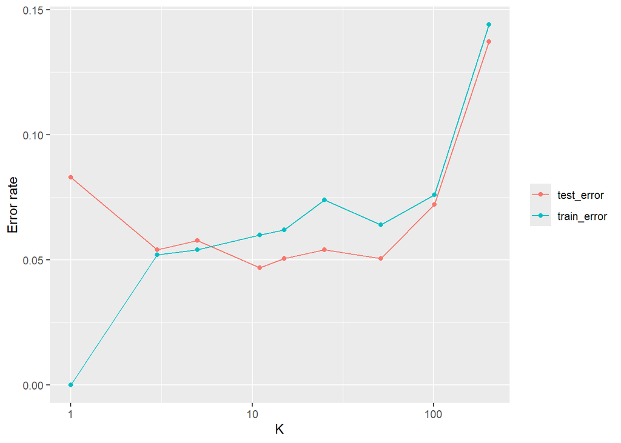

```r
results_long <- results %>%
  pivot_longer(c(train_error, test_error), names_to = "set", values_to = "error")

ggplot(results_long, aes(K, error, color = set)) +
  geom_line() +
  geom_point() +
  scale_x_log10() +
  labs(y = "Error rate", color = NULL)
```

The lowest test error is **4.7%**, at K = 11, against logistic regression’s 5.1%. That’s 13 mistakes vs 14 out of 277 test colleges: essentially a tie on these two predictors.

Picking K by **training** error would always pick K = 1 (training error 0), the most overfit choice. Training error rewards memorizing; only the test error tells you how the method does on new colleges.

At K = 201, each vote polls 201 of the 500 training colleges, about 40% of the whole training set. With 72% of training colleges private, most of those big neighborhoods lean private even around a cheap public school, so KNN calls too many colleges private. The test error climbs to 13.7%. Push K toward 500 and every vote becomes the whole training set: KNN turns into the “everyone is private” baseline. **High bias, low variance.**

## Part 4: Dollars vs Thousands

### Task 4.1: Change the units

```r
train_X_dollars <- train %>% select(Outstate, undergrad)
test_X_dollars  <- test %>% select(Outstate, undergrad)

set.seed(1)
pred_dollars <- knn(train_X_dollars, test_X_dollars, cl = train$Private, k = 11)
mean(pred_dollars != test$Private)
```

```
## [1] 0.1732852
```

The error rate jumps from 4.7% to **17.3%**. The colleges are the same; only the units changed. Distance adds up squared differences, and tuition in dollars differs by thousands between colleges while `undergrad` differs by single digits. So **tuition alone** decides who is “nearest,” and enrollment, which helps separate big public universities from small private colleges, is ignored.

### Task 4.2: Standardize

```r
College_std <- scale(College %>% select(Outstate, undergrad))
train_X_std <- College_std[train_rows, ]
test_X_std  <- College_std[-train_rows, ]
```

```r
set.seed(1)
pred_std <- knn(train_X_std, test_X_std, cl = train$Private, k = 11)
mean(pred_std != test$Private)
```

```
## [1] 0.05054152
```

Standardized, the test error rate is **5.1%**, back in line with Part 3. Measuring tuition in cents would **not** change it: standardizing divides by each variable’s own standard deviation, so the units cancel. Each predictor now counts in “standard deviations from the mean,” on equal footing.

(In Parts 2–3, tuition and enrollment were both in thousands and happened to have similar spreads, so KNN worked without standardizing. That was luck, not design.)

## Bonus

### Bonus 1: A different split

```r
best_k_for_seed <- function(seed) {
  set.seed(seed)
  rows <- sample(nrow(College), 500)
  tr <- College[rows, ]; te <- College[-rows, ]
  trX <- tr %>% select(tuition, undergrad); teX <- te %>% select(tuition, undergrad)
  set.seed(1)
  errs <- sapply(k_values, function(k) mean(knn(trX, teX, cl = tr$Private, k = k) != te$Private))
  lg <- glm(Private ~ tuition + undergrad, data = tr, family = binomial)
  tibble(seed = seed,
         best_K = paste(k_values[errs == min(errs)], collapse = ", "),
         best_knn_error = min(errs),
         logistic_error = mean(ifelse(predict(lg, te, type = "response") > 0.5, "Yes", "No") != te$Private))
}
bind_rows(lapply(c(122, 1, 13, 2026), best_k_for_seed))
```

```
## # A tibble: 4 × 4
##    seed best_K     best_knn_error logistic_error
##   <dbl> <chr>               <dbl>          <dbl>
## 1   122 11                 0.0469         0.0505
## 2     1 11, 15, 51         0.0542         0.0542
## 3    13 11                 0.0469         0.0614
## 4  2026 5, 51              0.0542         0.0505
```

The best K and both error rates move around from split to split, and so does which method “wins.” With only 277 test colleges, one or two colleges change the error rate by about 0.4 percentage points. A single split is a noisy estimate of test error; Day 14’s cross-validation averages over several splits.

### Bonus 2: More predictors

```r
vars <- c("Outstate", "undergrad", "Grad.Rate", "perc.alumni", "S.F.Ratio")
College_std5 <- scale(College %>% select(all_of(vars)))

set.seed(1)
pred_knn5 <- knn(College_std5[train_rows, ], College_std5[-train_rows, ],
                 cl = train$Private, k = 11)
mean(pred_knn5 != test$Private)
```

```
## [1] 0.07942238
```

```r
fit_logit5 <- glm(Private ~ tuition + undergrad + Grad.Rate + perc.alumni + S.F.Ratio,
                  data = train, family = binomial)
mean(ifelse(predict(fit_logit5, test, type = "response") > 0.5, "Yes", "No") != test$Private)
```

```
## [1] 0.05054152
```

No. KNN gets **worse**: 7.9% with five predictors vs 4.7% with two. Logistic regression goes from 5.1% to 5.1%. Tuition and size already carry most of the information. For KNN, weak predictors also add noise to the distance: two colleges that match on tuition and size can look “far apart” because they differ on a variable that doesn’t matter. Logistic regression can give a weak predictor a small coefficient; KNN counts every predictor equally.

### Bonus 3: Which would you ship?

With equal test error, logistic regression is the better choice for the website. It’s small (three coefficients instead of the whole training set), fast, and it can **explain** itself: “colleges with higher tuition and fewer undergraduates are more likely to be private,” with a probability attached. KNN can only say “the 11 most similar colleges were mostly private,” which is honest but tells the user nothing about which features mattered.